# Linear_Model_ClassNote_SK

Shakiba Kazemian

2025-04-01

## **Class Notes: Introduction to Regression Analysis in R**

### **1. Linear Regression Basics**

- The linear regression model:  
  **y = β₀ + β₁x + ε**, where:
  - **y** = response variable
  - **x** = predictor
  - **β₀** = intercept
  - **β₁** = slope
  - **ε ~ N(0, σ)** = error term (normally distributed)
- **Goals**: Estimate slope, intercept, and error (σ).
- **Objective**: Minimize **SSE (Sum of Squared Errors)**.
- **P-value**: Measures the probability the result is due to chance.
  - Null hypothesis: **β₁ = 0** (no slope).
  - Smaller p-values = stronger evidence against the null.

### **2. Regression in R Using `mtcars`**

- Dataset: `mtcars`
- Visualize: Scatterplot with a regression line using `ggplot2`.

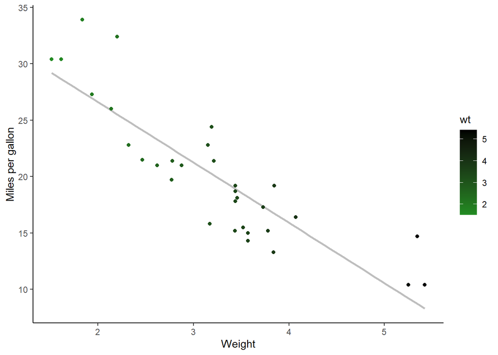

```r
ggplot(mtcars, aes(x = wt, y = mpg)) +
  geom_smooth(method = lm, se = FALSE, color = "grey") +
  geom_point(aes(color = wt)) +
  xlab("Weight") +
  ylab("Miles per gallon") +
  scale_colour_gradient(low = "forestgreen", high = "black") +
  theme_classic()
```

- Fit linear model with the function `lm()`:

```r
lm(mpg ~ wt, data = mtcars) # linear relationship between weight (wt) and miles per gallon (mpg)
```

```
##
## Call:
## lm(formula = mpg ~ wt, data = mtcars)
##
## Coefficients:
## (Intercept)           wt
##      37.285       -5.344
```

```r
summary(lm(mpg ~ wt, data = mtcars))
```

```
##
## Call:
## lm(formula = mpg ~ wt, data = mtcars)
##
## Residuals:
##     Min      1Q  Median      3Q     Max
## -4.5432 -2.3647 -0.1252  1.4096  6.8727
##
## Coefficients:
##             Estimate Std. Error t value Pr(>|t|)
## (Intercept)  37.2851     1.8776  19.858  < 2e-16 ***
## wt           -5.3445     0.5591  -9.559 1.29e-10 ***
## ---
## Signif. codes:  0 '***' 0.001 '**' 0.01 '*' 0.05 '.' 0.1 ' ' 1
##
## Residual standard error: 3.046 on 30 degrees of freedom
## Multiple R-squared:  0.7528, Adjusted R-squared:  0.7446
## F-statistic: 91.38 on 1 and 30 DF,  p-value: 1.294e-10
```

### **3. ANOVA and Correlation**

- ANOVA on linear model:

```r
anova(lm(mpg ~ wt, data = mtcars)) # Tells us if the effect of wt on mpg is significant
```

```
## Analysis of Variance Table
##
## Response: mpg
##           Df Sum Sq Mean Sq F value    Pr(>F)
## wt         1 847.73  847.73  91.375 1.294e-10 ***
## Residuals 30 278.32    9.28
## ---
## Signif. codes:  0 '***' 0.001 '**' 0.01 '*' 0.05 '.' 0.1 ' ' 1
```

- Correlation test:

```r
cor.test(mtcars$wt, mtcars$mpg) # Tells us if there is a correlation between wt and mpg
```

```
##
##  Pearson's product-moment correlation
##
## data:  mtcars$wt and mtcars$mpg
## t = -9.559, df = 30, p-value = 1.294e-10
## alternative hypothesis: true correlation is not equal to 0
## 95 percent confidence interval:
##  -0.9338264 -0.7440872
## sample estimates:
##        cor
## -0.8676594
```

### **4. Regression Assumptions**

- Assumptions:
  - y is continuous
  - Error is normal
  - Linear relationship
  - Homoskedasticity (constant σ)
  - Independence
- Violations have minor impacts unless severe.
- Get the residuals from our linear model:

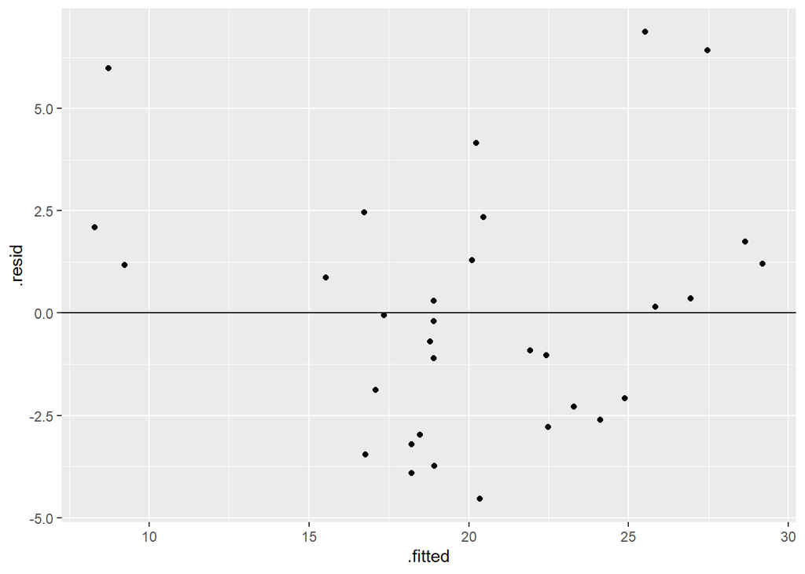

```r
model <- lm(mpg~wt, data = mtcars)

ggplot(model, aes(y = .resid, x = .fitted)) +
  geom_point() +
  geom_hline(yintercept = 0)
```

## **5. T-tests as Linear Models**

- Use t-tests when x is categorical and y is continuous.
- Example: Fungicide effect on richness.
- Loading richness dataset.

```r
bull.rich <- read.csv("Bull_richness.csv")
```

- Filtering our dataset to include one treatment and growth stage for demonstration of a t-test.

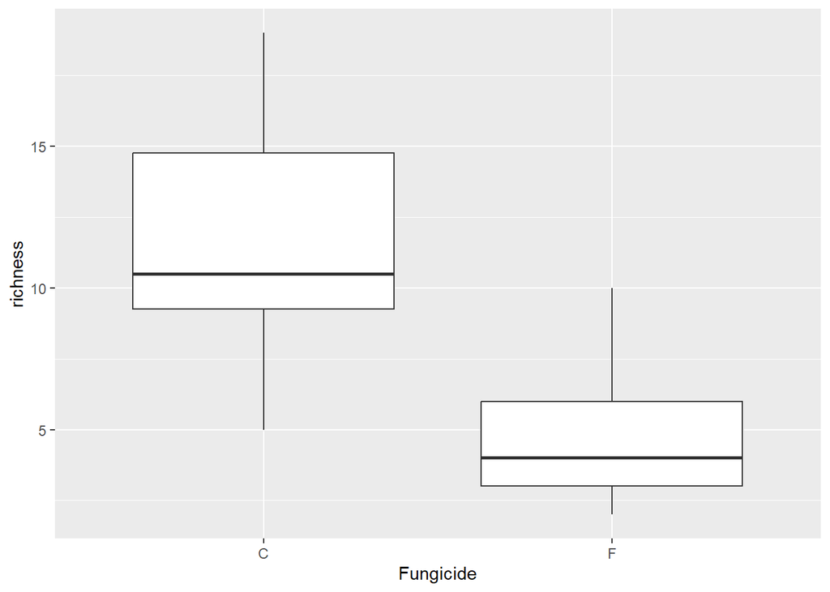

```r
library(tidyverse)
bull.rich %>%
  filter(GrowthStage == "V8" & Treatment == "Conv.") %>%
  ggplot(aes(x = Fungicide, y = richness)) +
  geom_boxplot()
```

- Running the t-test where the null hypothesis is that there is no difference in group means.

```r
bull.rich.sub <- bull.rich %>%
  filter(GrowthStage == "V8" & Treatment == "Conv.")

t.test(richness~Fungicide, data = bull.rich.sub)
```

```
##
##  Welch Two Sample t-test
##
## data:  richness by Fungicide
## t = 4.8759, df = 17.166, p-value = 0.0001384
## alternative hypothesis: true difference in means between group C and group F is not equal to 0
## 95 percent confidence interval:
##   4.067909 10.265425
## sample estimates:
## mean in group C mean in group F
##       11.750000        4.583333
```

```r
summary(lm(richness ~ Fungicide, data = bull.rich.sub))
```

```
##
## Call:
## lm(formula = richness ~ Fungicide, data = bull.rich.sub)
##
## Residuals:
##     Min      1Q  Median      3Q     Max
## -6.7500 -1.7500 -0.6667  2.2500  7.2500
##
## Coefficients:
##             Estimate Std. Error t value Pr(>|t|)
## (Intercept)   11.750      1.039  11.306 1.24e-10 ***
## FungicideF    -7.167      1.470  -4.876 7.12e-05 ***
## ---
## Signif. codes:  0 '***' 0.001 '**' 0.01 '*' 0.05 '.' 0.1 ' ' 1
##
## Residual standard error: 3.6 on 22 degrees of freedom
## Multiple R-squared:  0.5194, Adjusted R-squared:  0.4975
## F-statistic: 23.77 on 1 and 22 DF,  p-value: 7.118e-05
```

```r
anova(lm(richness ~ Fungicide, data = bull.rich.sub))
```

```
## Analysis of Variance Table
##
## Response: richness
##           Df Sum Sq Mean Sq F value    Pr(>F)
## Fungicide  1 308.17 308.167  23.774 7.118e-05 ***
## Residuals 22 285.17  12.962
## ---
## Signif. codes:  0 '***' 0.001 '**' 0.01 '*' 0.05 '.' 0.1 ' ' 1
```

- T-tests and regression yield the same p-values when assumptions hold.
- The slope β₁ represents the difference between group means.

## **6. ANOVA with Multiple Groups**

```r
bull.rich.sub2 <- bull.rich %>%
  filter(Fungicide == "C" & Treatment == "Conv." & Crop == "Corn")
```

- Visualize the data

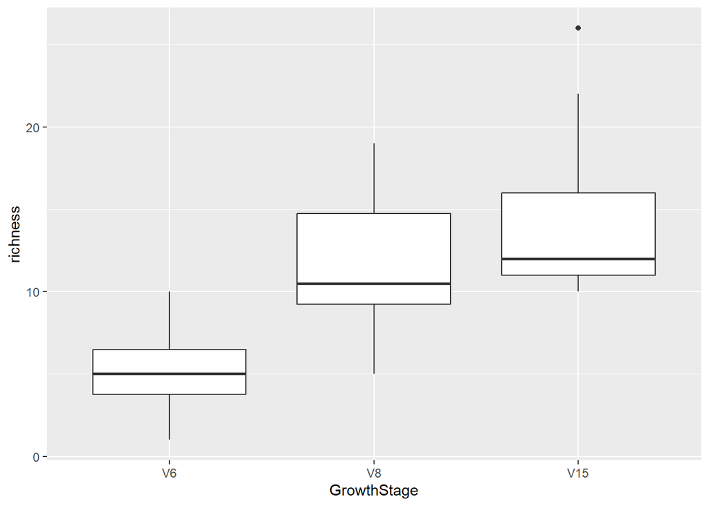

```r
bull.rich.sub2$GrowthStage <- factor(bull.rich.sub2$GrowthStage, levels = c("V6", "V8", "V15"))

ggplot(bull.rich.sub2, aes(x = GrowthStage, y = richness)) +
  geom_boxplot()
```

- Set up the linear model and run ANOVAs

```r
lm.growth <- lm(richness ~ GrowthStage, data = bull.rich.sub2)
summary(lm.growth)
```

```
##
## Call:
## lm(formula = richness ~ GrowthStage, data = bull.rich.sub2)
##
## Residuals:
##    Min     1Q Median     3Q    Max
## -6.750 -2.625 -1.000  2.250 11.583
##
## Coefficients:
##                Estimate Std. Error t value Pr(>|t|)
## (Intercept)       5.250      1.208   4.348 0.000124 ***
## GrowthStageV8     6.500      1.708   3.806 0.000581 ***
## GrowthStageV15    9.167      1.708   5.368 6.23e-06 ***
## ---
## Signif. codes:  0 '***' 0.001 '**' 0.01 '*' 0.05 '.' 0.1 ' ' 1
##
## Residual standard error: 4.183 on 33 degrees of freedom
## Multiple R-squared:  0.4803, Adjusted R-squared:  0.4488
## F-statistic: 15.25 on 2 and 33 DF,  p-value: 2.044e-05
```

```r
anova(lm.growth)
```

```
## Analysis of Variance Table
##
## Response: richness
##             Df Sum Sq Mean Sq F value    Pr(>F)
## GrowthStage  2 533.56 266.778  15.247 2.044e-05 ***
## Residuals   33 577.42  17.497
## ---
## Signif. codes:  0 '***' 0.001 '**' 0.01 '*' 0.05 '.' 0.1 ' ' 1
```

```r
summary(aov(richness ~ GrowthStage, data = bull.rich.sub2))
```

```
##             Df Sum Sq Mean Sq F value   Pr(>F)
## GrowthStage  2  533.6   266.8   15.25 2.04e-05 ***
## Residuals   33  577.4    17.5
## ---
## Signif. codes:  0 '***' 0.001 '**' 0.01 '*' 0.05 '.' 0.1 ' ' 1
```

[output not shown]

```
## $emmeans
##  GrowthStage emmean   SE df lower.CL upper.CL .group
##  V15          14.42 1.21 33    11.96    16.87  1
##  V8           11.75 1.21 33     9.29    14.21  1
##  V6            5.25 1.21 33     2.79     7.71   2
##
## Confidence level used: 0.95
## P value adjustment: tukey method for comparing a family of 3 estimates
## significance level used: alpha = 0.05
## NOTE: If two or more means share the same grouping symbol,
##       then we cannot show them to be different.
##       But we also did not show them to be the same.
##
## $comparisons
##  contrast estimate   SE df t.ratio p.value
##  V8 - V6      6.50 1.71 33   3.806  0.0016
##  V15 - V6     9.17 1.71 33   5.368  <.0001
##  V15 - V8     2.67 1.71 33   1.562  0.2763
##
## P value adjustment: tukey method for comparing a family of 3 estimates
```

## **7. Interaction Terms**

Lets filter our dataset to include fungicide term.

```r
bull.rich.sub3 <- bull.rich %>%
  filter(Treatment == "Conv." & Crop == "Corn")

bull.rich.sub3$GrowthStage <- factor(bull.rich.sub3$GrowthStage, levels = c("V6", "V8", "V15"))
```

- Check if one variable’s effect depends on another:

```r
lm(richness ~ GrowthStage * Fungicide, data = bull.rich.sub3)
```

```
##
## Call:
## lm(formula = richness ~ GrowthStage * Fungicide, data = bull.rich.sub3)
##
## Coefficients:
##               (Intercept)              GrowthStageV8
##                    5.2500                     6.5000
##            GrowthStageV15                 FungicideF
##                    9.1667                    -1.2500
##  GrowthStageV8:FungicideF  GrowthStageV15:FungicideF
##                   -5.9167                     0.3333
```

- Significant interaction implies effect of fungicide varies across stages.
- Visualize with `ggplot2`.

### **Post-hoc on Interaction**

- Split comparison within growth stages:

```r
lm.inter <- lm(richness ~ GrowthStage * Fungicide, data = bull.rich.sub3)

lsmeans <- emmeans(lm.inter, ~Fungicide | GrowthStage)
cld(lsmeans, alpha = 0.05)
```

```
## GrowthStage = V6:
##  Fungicide emmean  SE df lower.CL upper.CL .group
##  F           4.00 1.1 66     1.80     6.20  1
##  C           5.25 1.1 66     3.05     7.45  1
##
## GrowthStage = V8:
##  Fungicide emmean  SE df lower.CL upper.CL .group
##  F           4.58 1.1 66     2.38     6.79  1
##  C          11.75 1.1 66     9.55    13.95   2
##
## GrowthStage = V15:
##  Fungicide emmean  SE df lower.CL upper.CL .group
##  F          13.50 1.1 66    11.30    15.70  1
##  C          14.42 1.1 66    12.21    16.62  1
##
## Confidence level used: 0.95
## significance level used: alpha = 0.05
## NOTE: If two or more means share the same grouping symbol,
##       then we cannot show them to be different.
##       But we also did not show them to be the same.
```

## **8. Mixed Effects Models**

- Distinction:
  - **Fixed effects**: affect the mean (e.g., Treatment, Species)
  - **Random effects**: affect variation (e.g., Year, Replicate)
- Use `lme4` package:

```r
lme0 <- lm(richness ~ GrowthStage * Fungicide, data = bull.rich.sub3)
lme1 <- lmer(richness ~ GrowthStage*Fungicide + (1|Rep), data = bull.rich.sub3)
```

### **Comparing Models**

- Compare models with and without random effects:

```r
anova(lme1, lme0)
```

```
## refitting model(s) with ML (instead of REML)
```

```
## Data: bull.rich.sub3
## Models:
## lme0: richness ~ GrowthStage * Fungicide
## lme1: richness ~ GrowthStage * Fungicide + (1 | Rep)
##      npar    AIC    BIC  logLik deviance  Chisq Df Pr(>Chisq)
## lme0    7 405.08 421.01 -195.54   391.08
## lme1    8 406.55 424.77 -195.28   390.55 0.5224  1     0.4698
```

- Adding random effects can improve model reliability and reduce standard errors.

### **Random vs. Fixed Misclassification**

- You *can* treat a fixed effect as random (e.g., GrowthStage), but you need logical justification.
- Even if it’s misclassified, the model will still work, but interpretation differs.

## **Summary**

- **Linear models** underpin many statistical tests (t-test, ANOVA, correlation).
- **Visualization** is key before modeling.
- **p-value** interpretation, **model assumptions**, and **model diagnostics** (like residual plots) are essential for proper analysis.
- Mixed models extend linear models to account for variability across random factors.